# HW1: Datatypes and Wrangling

Yosefe Eshete

Feb 2, 2020

## Data Types

*1) Provide a URL to the dataset.* https://www.kaggle.com/hakabuk/gun-deaths-in-the-us

*2) Explain why you chose this dataset.* I'm interested in knowing how race factors into gun deaths that involve police.

*3) What are the entities in this dataset? How many are there?* Individual deaths, there are 100789 entities.

*4) How many attributes are there in this dataset?* There are 10 attributes.

*5) What is the datatype of each attribute (categorical -ordered or unordered-, numeric -discrete or continuous-, datetime, geolocation, other)? Write a short sentence stating how you determined the type of each attribute. Do this for at least 5 attributes, if your dataset contains more than 10 attributes, choose 10 of them to describe.*

| Num | Name | Type | Description |
| --- | --- | --- | --- |
| 1 | Police | Categorical unordered | Police involvement, true or false |
| 2 | Intent | Categorical unordered | Suicide, Accidental, NA, Homicide, Undetermined |
| 3 | Race | Categorical unordered | race of the individual |
| 4 | Education | Categorical ordered | level of education ranked from 1 to 4 |
| 5 | Sex | Categorical unordered | Male or female |

_6) Write python code that loads the dataset using function `pd.read_csv`. Were you able to load the data successfully? If no, why not?_ I wasn't able to load my dataset properly at the start, but after I copied my data into a .cvs file in the same folder and stated the delimiter I was able to load my data properly.

```python
import pandas as pd
deaths_tab = pd.read_csv('guns.csv', delimiter = '	')

# loading code goes here
```

```python
deaths_tab.head()
```

|  | Unnamed: 0 | year | month | intent | police | sex | age | race | hispanic | place | education |
| --- | --- | --- | --- | --- | --- | --- | --- | --- | --- | --- | --- |
| 0 | 1 | 2012 | 1 | Suicide | 0 | M | 34.0 | Asian/Pacific Islander | 100 | Home | 4.0 |
| 1 | 2 | 2012 | 1 | Suicide | 0 | F | 21.0 | White | 100 | Street | 3.0 |
| 2 | 3 | 2012 | 1 | Suicide | 0 | M | 60.0 | White | 100 | Other specified | 4.0 |
| 3 | 4 | 2012 | 2 | Suicide | 0 | M | 64.0 | White | 100 | Home | 4.0 |
| 4 | 5 | 2012 | 2 | Suicide | 0 | M | 31.0 | White | 100 | Other specified | 2.0 |

## Wrangling

```python
police_deaths = (deaths_tab[['police','age','race']]
                .query('age > 18')
                .query('age < 30')
                .query('police > 0')
                 .groupby(['race'])
                 .agg({'police': 'sum'})
                 .reset_index()
                 )
police_deaths
```

|  | race | police |
| --- | --- | --- |
| 0 | Asian/Pacific Islander | 15 |
| 1 | Black | 162 |
| 2 | Hispanic | 106 |
| 3 | Native American/Native Alaskan | 14 |
| 4 | White | 184 |

## Plotting

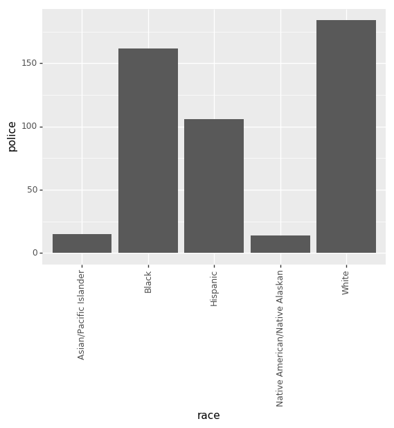

```python
from plotnine import *

(ggplot(police_deaths, aes(x='race', y='police')) + theme(axis_text_x = element_text(angle=90)) + geom_bar(stat='identity') )
```